# Milestone 5

Amy Zhou

3/20/2020

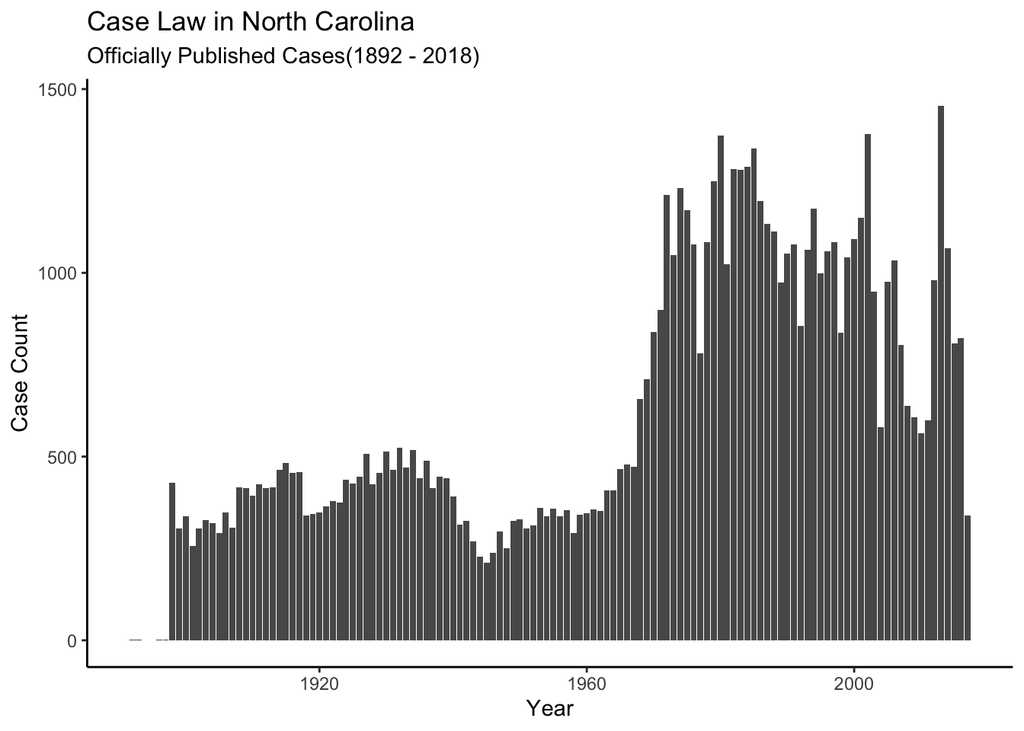

## Disclaimer:

This graph is a far simplified version of the graph I had earlier. Unfortunately after losing the csv I was working off of as well as the majority of my code, I was unable to manipulate the data as I had before (in the csv, the court dataframe column had been unnested so I could access the court names to court cases based on court). I tried to recreate the csv with write_csv, fwrite but ran into errors every time. I also tried to run unnest() also with no success. Thus I had to settle for just counting by year and not year and court. I am continuing to work on trying to figure out the csv or unnesting.

I however, also reconstructed some of my previous code in the form of north_carolina.rmd. It is on my repo here if you would like to see: https://github.com/amyzhou9/gov1005-final-project